# homework3

## Analysing Amazon Reviews by pandas

Same Question with last week:

> "there is a positive relationship between the food price, and review scores for the food.If one kind of food is more expensive then comparatively this one could get higher score."

#### Load pickle file of product which teacher adjested in course

#### Screening the items which don't have the key "price"

```python
import json
import pandas as pd
from pandas import Series,DataFrame

# Loading File
products = pd.read_pickle('products.pickle')
list_drop = []

## Screening
for i in range(0,len(products)):
    if products.price.isnull()[i] == True:
        list_drop.append(products.price.index[i])

for i in range(0,len(list_drop)):
    products.drop(list_drop[i],inplace=True)
```

#### Load pickle file of reviews which teacher adjested in course

#### Get the reviews count and mean values

#### Drop those items which don't have key "price"

```python
#Load file

reviews = pd.read_pickle('reviews.pickle')
list_average = []
counts = reviews.asin.value_counts()
#Get the reviews count and mean values
stats = reviews.groupby(['asin'])['overall'].agg(['count','mean'])

#Screening the items
for i in range(0,len(list_drop)):
    stats.drop(list_drop[i],inplace=True)
```

#### Get Lists of price and the average reviews score

#### Plotting the scatter like last week

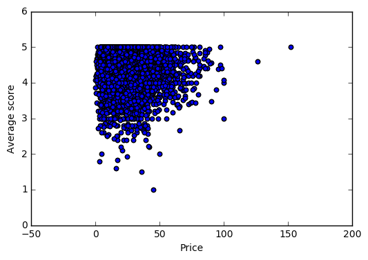

```python
from matplotlib import pyplot as plt

stats_mean = stats['mean']
reviews_mean = list(stats_mean)
list_price = list(products.price)
plt.scatter(list_price,reviews_mean)
plt.xlabel("Price")
plt.ylabel("Average score")
plt.show()
```

### Bonus Part!

In last week, I used a complicated method to get both lists. For testing its running time, I adjested all my codes in week into a object-oriented model. So that I could easily test different modules by lines.The codes are wrote as below.

```python
from matplotlib import pyplot as plt
import json
products = json.load(open('gourmet_products.json'))
reviews = json.load(open('gourmet_reviews.json'))

class screening_price:
    def __init__(self):
        self.reviews = reviews
        self.products = products
        self.list_id = []
        self.list_id_no_price = []
        self.price_list = []
        self.dict_price = {}

    def primary_list_id(self):
        t = set()
        for item in self.reviews:
            t.add(item['asin'])
        self.list_id = list(t)
        return self.list_id

    def screening(self):
        for id in self.list_id:
            if('price' in self.products[id].keys()):
                self.dict_price[id] = self.products[id]['price']
            else:
                self.list_id_no_price.append(id)
                continue
        return self.list_id

    def difference_set(self):
        self.list_id = list(set(self.list_id).difference(set(self.list_id_no_price)))
        print(len(self.list_id))
        for key in self.dict_price:
            self.price_list.append(self.dict_price[key])
        return self.price_list

    def execute(self):
        self.primary_list_id()
        self.screening()
        self.difference_set()
        return self.list_id

class get_reviews:
    def __init__(self):
        self.reviews = reviews
        self.list_id = list_id
        self.list_single_item = []
        self.list_single_total = []
        self.list_everyitem_length = []
        self.p_reviews = {}
        self.results = []

    def get_all_reviews(self):
        for review in reviews:
            asin = review['asin']
            if asin not in self.p_reviews:
                self.p_reviews[asin] = [review]#等于list形式的review,"B0039QXWZM":"["...."]"
            else:
                self.p_reviews[asin].append(review)#何苦呢搞得好晕啊
        return self.p_reviews

    def get_item_total_scores(self):
        su = 0
        for i in self.list_id:
            self.list_single_total.append(su)
            self.list_single_item = []
            for j in range(len(self.p_reviews[i])):
                length = len(self.p_reviews[i])
                self.list_single_item.append(self.p_reviews[i][j]['overall'])
                su = sum(self.list_single_item)

        for i in self.list_id:
            self.list_everyitem_length.append(len(self.p_reviews[i]))

        return self.list_single_item
        print(self.list_single_item)

        #self.list_everyitem_length
    def adject_list(self):
        last_value = self.list_single_total[0]
        self.list_single_total.pop(0)
        self.list_single_total.append(last_value)
        return self.list_single_total

    def divide(self):
        f = lambda x,y : x / y
        results = map(f,self.list_single_total,self.list_everyitem_length)
        results = list(results)
        return results

    def execute(self):
        self.get_all_reviews()
        self.get_item_total_scores()
        self.adject_list()
        self.divide()

S = screening_price()
%timeit -n 2 S.difference_set() ## speed of getting price_list
list_id = S.execute()
R = get_reviews()
R.execute()
%timeit -n 2 results = R.divide() ## speed of getting reviews_score_list
```

```
0
0
0
0
0
0
The slowest run took 4.17 times longer than the fastest. This could mean that an intermediate result is being cached.
2 loops, best of 3: 10.9 µs per loop
7366
2 loops, best of 3: 1.97 ms per loop
```

```python
import json
import pandas as pd
from pandas import Series,DataFrame

# Loading File
list_drop_total = []
def price_list():
    products = pd.read_pickle('products.pickle')
    list_drop = []

## Screening
    for i in range(0,len(products)):
        if products.price.isnull()[i] == True:
            list_drop.append(products.price.index[i])

    for i in range(0,len(list_drop)):
        products.drop(list_drop[i],inplace=True)

    list_drop_total = list_drop
    return products
%timeit -n 2 list(price_list().price)
```

```
2 loops, best of 3: 7.77 s per loop
```

```python
#Load file
def review_p():
    reviews = pd.read_pickle('reviews.pickle')
    list_average = []
    counts = reviews.asin.value_counts()
    #Get the reviews count and mean values
    stats = reviews.groupby(['asin'])['overall'].agg(['count','mean'])

    #Screening the items
    for i in range(0,len(list_drop_total)):
        stats.drop(list_drop[i],inplace=True)
    return stats

%timeit -n 2 list(review_p()['mean'])
```

```
2 loops, best of 3: 438 ms per loop
```

Why was it slower than I wrote in last week? Becasue in this week I use many loops method in my codes to screen the items I don't need to.If I compare the speed of just a single line wrote by pandas and its correspondent method in plain python. I found lines by pandas are still slower...

```python
reviews = pd.read_pickle('reviews.pickle')
list_average = []
counts = reviews.asin.value_counts()
#Get the reviews count and mean values
%timeit -n 2 reviews.groupby(['asin'])['overall'].agg(['count','mean'])
# which is slower than speed of getting reviews_score_list : which took 1.97 ms per loop...
```

```
2 loops, best of 3: 17.5 ms per loop
```